# Assignment

Dixxanta Shrestha

2023-10-27

Importing important libraries

```r
require('ggplot2')
require('dplyr')
require('tidyr')
```

The first step is to import the data and view it

```r
employee_data <-read.csv('C:/Users/97798/Documents/sem 4 materials/SEM 4/CT127-3-2-PFDA/Assignment - Individual/employee_attrition.csv')
head(employee_data)
```

```
##   EmployeeID  recorddate_key birthdate_key orighiredate_key terminationdate_key
## 1       1318 12/31/2006 0:00      1/3/1954        8/28/1989            1/1/1900
## 2       1318 12/31/2007 0:00      1/3/1954        8/28/1989            1/1/1900
## 3       1318 12/31/2008 0:00      1/3/1954        8/28/1989            1/1/1900
## 4       1318 12/31/2009 0:00      1/3/1954        8/28/1989            1/1/1900
## 5       1318 12/31/2010 0:00      1/3/1954        8/28/1989            1/1/1900
## 6       1318 12/31/2011 0:00      1/3/1954        8/28/1989            1/1/1900
##   age length_of_service city_name department_name job_title store_name
## 1  52                17 Vancouver       Executive       CEO         35
## 2  53                18 Vancouver       Executive       CEO         35
## 3  54                19 Vancouver       Executive       CEO         35
## 4  55                20 Vancouver       Executive       CEO         35
## 5  56                21 Vancouver       Executive       CEO         35
## 6  57                22 Vancouver       Executive       CEO         35
##   gender_short gender_full termreason_desc  termtype_desc STATUS_YEAR STATUS
## 1            M        Male  Not Applicable Not Applicable        2006 ACTIVE
## 2            M        Male  Not Applicable Not Applicable        2007 ACTIVE
## 3            M        Male  Not Applicable Not Applicable        2008 ACTIVE
## 4            M        Male  Not Applicable Not Applicable        2009 ACTIVE
## 5            M        Male  Not Applicable Not Applicable        2010 ACTIVE
## 6            M        Male  Not Applicable Not Applicable        2011 ACTIVE
##   BUSINESS_UNIT
## 1    HEADOFFICE
## 2    HEADOFFICE
## 3    HEADOFFICE
## 4    HEADOFFICE
## 5    HEADOFFICE
## 6    HEADOFFICE
```

The first step is to check for missing values. there is not missing values

```r
missing_data = colSums(is.na(employee_data))
print(missing_data)
```

```
##          EmployeeID      recorddate_key       birthdate_key    orighiredate_key
##                   0                   0                   0                   0
## terminationdate_key                 age   length_of_service           city_name
##                   0                   0                   0                   0
##     department_name           job_title          store_name        gender_short
##                   0                   0                   0                   0
##         gender_full     termreason_desc       termtype_desc         STATUS_YEAR
##                   0                   0                   0                   0
##              STATUS       BUSINESS_UNIT
##                   0                   0
```

There is no missing data Now understanding data structure

```r
str(employee_data)
```

```
## 'data.frame':    49653 obs. of  18 variables:
##  $ EmployeeID         : int  1318 1318 1318 1318 1318 1318 1318 1318 1318 1318 ...
##  $ recorddate_key     : chr  "12/31/2006 0:00" "12/31/2007 0:00" "12/31/2008 0:00" "12/31/2009 0:00" ...
##  $ birthdate_key      : chr  "1/3/1954" "1/3/1954" "1/3/1954" "1/3/1954" ...
##  $ orighiredate_key   : chr  "8/28/1989" "8/28/1989" "8/28/1989" "8/28/1989" ...
##  $ terminationdate_key: chr  "1/1/1900" "1/1/1900" "1/1/1900" "1/1/1900" ...
##  $ age                : int  52 53 54 55 56 57 58 59 60 61 ...
##  $ length_of_service  : int  17 18 19 20 21 22 23 24 25 26 ...
##  $ city_name          : chr  "Vancouver" "Vancouver" "Vancouver" "Vancouver" ...
##  $ department_name    : chr  "Executive" "Executive" "Executive" "Executive" ...
##  $ job_title          : chr  "CEO" "CEO" "CEO" "CEO" ...
##  $ store_name         : int  35 35 35 35 35 35 35 35 35 35 ...
##  $ gender_short       : chr  "M" "M" "M" "M" ...
##  $ gender_full        : chr  "Male" "Male" "Male" "Male" ...
##  $ termreason_desc    : chr  "Not Applicable" "Not Applicable" "Not Applicable" "Not Applicable" ...
##  $ termtype_desc      : chr  "Not Applicable" "Not Applicable" "Not Applicable" "Not Applicable" ...
##  $ STATUS_YEAR        : int  2006 2007 2008 2009 2010 2011 2012 2013 2014 2015 ...
##  $ STATUS             : chr  "ACTIVE" "ACTIVE" "ACTIVE" "ACTIVE" ...
##  $ BUSINESS_UNIT      : chr  "HEADOFFICE" "HEADOFFICE" "HEADOFFICE" "HEADOFFICE" ...
```

The data stores and updates employee data in the same file. Each year a new record is added for example 1318 the ceo has been working from 2006 to 2015 and thier data is updated each year.

convert all date columns to date

```r
cols = colnames(employee_data)
for (col in cols){
  if(length(grep("date",col))){
   employee_data[[col]] = as.Date(employee_data[[col]], format = "%m/%d/%Y")
  }
}
```

```r
str(employee_data)
```

```
## 'data.frame':    49653 obs. of  18 variables:
##  $ EmployeeID         : int  1318 1318 1318 1318 1318 1318 1318 1318 1318 1318 ...
##  $ recorddate_key     : Date, format: "2006-12-31" "2007-12-31" ...
##  $ birthdate_key      : Date, format: "1954-01-03" "1954-01-03" ...
##  $ orighiredate_key   : Date, format: "1989-08-28" "1989-08-28" ...
##  $ terminationdate_key: Date, format: "1900-01-01" "1900-01-01" ...
##  $ age                : int  52 53 54 55 56 57 58 59 60 61 ...
##  $ length_of_service  : int  17 18 19 20 21 22 23 24 25 26 ...
##  $ city_name          : chr  "Vancouver" "Vancouver" "Vancouver" "Vancouver" ...
##  $ department_name    : chr  "Executive" "Executive" "Executive" "Executive" ...
##  $ job_title          : chr  "CEO" "CEO" "CEO" "CEO" ...
##  $ store_name         : int  35 35 35 35 35 35 35 35 35 35 ...
##  $ gender_short       : chr  "M" "M" "M" "M" ...
##  $ gender_full        : chr  "Male" "Male" "Male" "Male" ...
##  $ termreason_desc    : chr  "Not Applicable" "Not Applicable" "Not Applicable" "Not Applicable" ...
##  $ termtype_desc      : chr  "Not Applicable" "Not Applicable" "Not Applicable" "Not Applicable" ...
##  $ STATUS_YEAR        : int  2006 2007 2008 2009 2010 2011 2012 2013 2014 2015 ...
##  $ STATUS             : chr  "ACTIVE" "ACTIVE" "ACTIVE" "ACTIVE" ...
##  $ BUSINESS_UNIT      : chr  "HEADOFFICE" "HEADOFFICE" "HEADOFFICE" "HEADOFFICE" ...
```

The data stores and updates employee data in the same file. Each year a new record is added for example 1318 the ceo has been working from 2006 to 2015 and thier data is updated each year. Firstly i will segreate create a new data with one row for one employee by fetching their latest record. First, group the records by employeeID, arrange them based on status and then recorddate in descending order. If the employee has terminated status that will be their latest record. If they have not yet been terminated then their latest recorddate will be their latest record.

```r
employee_latest_record <- employee_data
employee_latest_record <- as.data.frame( employee_latest_record %>%
  group_by(EmployeeID) %>%
  arrange(desc(STATUS), desc(recorddate_key)) %>%
  slice(1) %>%
  ungroup())
```

Now, getting the summary for Numerical vairables

```r
numerical_columns <- c("age", "length_of_service")
summary(employee_latest_record[,numerical_columns])
```

```
##       age        length_of_service
##  Min.   :19.00   Min.   : 0.00
##  1st Qu.:32.00   1st Qu.: 7.00
##  Median :45.00   Median :13.00
##  Mean   :44.74   Mean   :12.84
##  3rd Qu.:58.00   3rd Qu.:19.00
##  Max.   :65.00   Max.   :26.00
```

Then, getting all the unique values for each Categorical variables

```r
categorical_columns <- c('city_name','department_name','job_title','store_name','gender_full','termreason_desc', 'termtype_desc','STATUS', 'BUSINESS_UNIT')
for ( category in categorical_columns){
#  unique_values <- toString(unique(employee_latest_record[[category]]))
  print(paste('The unique vairables in ',category,'column are:') )
  print(unique(employee_latest_record[category]))
}
```

```
## [1] "The unique vairables in  city_name column are:"
##             city_name
## 1           Vancouver
## 9             Terrace
## 11            Nanaimo
## 16             Nelson
## 17            Kelowna
## 19           Victoria
## 25           Kamloops
## 33       Fort St John
## 35             Surrey
## 45             Vernon
## 49            Quesnel
## 51         Chilliwack
## 59       Dawson Creek
```

[output cut: 170 more lines]

Getting descriptive statistics to understand the employee population

Total number of employees

```r
total_employee <- length(employee_latest_record$EmployeeID)
print(paste('There are ',total_employee,'employees in the company'))
```

```
## [1] "There are  6284 employees in the company"
```

Total number of employees by categories Gender

```r
male_employee_count <- nrow(employee_latest_record[employee_latest_record$gender_full == "Male",])
print(paste('There are ',male_employee_count,'male employees in the company'))
```

```
## [1] "There are  3006 male employees in the company"
```

```r
female_employee_count <- nrow(employee_latest_record[employee_latest_record$gender_full != "Male",])
print(paste('There are ',female_employee_count,'female employees in the company'))
```

```
## [1] "There are  3278 female employees in the company"
```

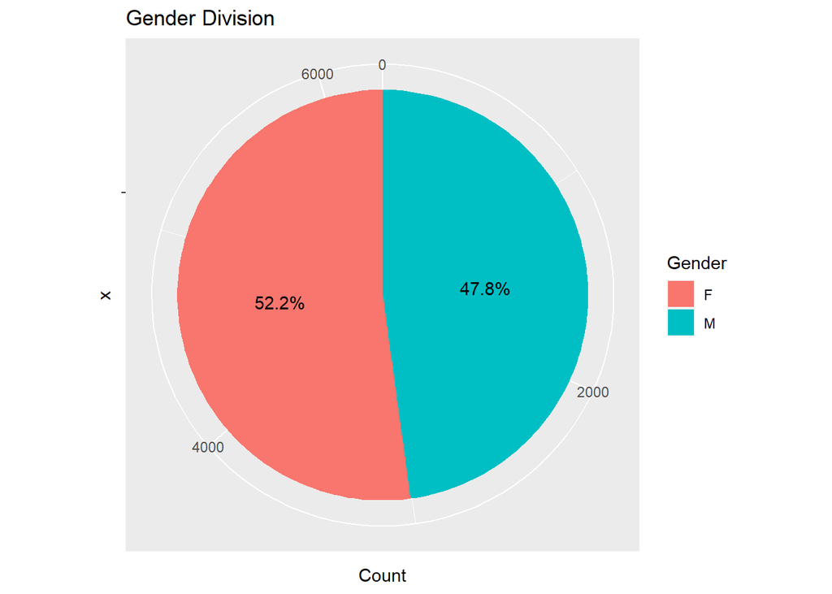

```r
gender_count_df <- employee_latest_record %>%
  group_by(gender_short) %>%
  summarise(count = n())
gender_count_df <- gender_count_df %>% mutate(percentage = ((count/total_employee)*100))
gender_count_df <- gender_count_df %>%
  rename(
    Gender = gender_short,
    Count = count,
    Percentage = percentage
  )
plot3 <- ggplot(gender_count_df, aes(x = "", y = Count, fill = Gender)) +
  geom_bar(stat = "identity", width = 1) +
  coord_polar("y") +
  labs(title = "Gender Division", fill = "Gender") +
  geom_text(aes(label = sprintf("%.1f%%", Percentage)), position = position_stack(vjust = 0.5))
show(plot3)
```

department_name

```r
department_employee_count <- employee_latest_record %>% group_by(department_name,STATUS) %>% count() %>% rename(counts = n) %>% arrange(desc(counts))
department_employee_count <- department_employee_count %>%
  arrange(desc(counts)) %>%
  mutate(department_name = reorder(department_name, counts))
department_employee_count
```

```
## # A tibble: 29 × 3
## # Groups:   department_name, STATUS [29]
##    department_name  STATUS     counts
##    <fct>            <chr>       <int>
##  1 Customer Service ACTIVE        928
##  2 Meats            ACTIVE        875
##  3 Dairy            ACTIVE        842
##  4 Bakery           ACTIVE        786
##  5 Produce          ACTIVE        707
##  6 Processed Foods  ACTIVE        646
##  7 Meats            TERMINATED    377
##  8 Produce          TERMINATED    353
##  9 Customer Service TERMINATED    262
## 10 Dairy            TERMINATED    191
## # ℹ 19 more rows
```

```r
department_employee_count <- employee_latest_record %>%
  group_by(department_name, STATUS) %>%
  count() %>%
  rename(counts = n) %>%
  arrange(desc(counts)) %>%
  mutate(department_name = reorder(department_name, counts))

# Filter for the top 7 departments
top7_departments <- department_employee_count %>%
  group_by(department_name) %>%
  summarize(total_counts = sum(counts)) %>%
  top_n(7, wt = total_counts) %>%
  pull(department_name)
top7_departments
```

```
## [1] Bakery           Customer Service Dairy            Meats
## [5] Processed Foods  Produce          Store Management
## 21 Levels: Accounting Accounts Payable Accounts Receiveable Audit ... Training
```

[figure not shown]

```r
library(ggplot2)


ggplot(department_employee_count[1:10,], aes(x = reorder(department_name, counts), y = counts,
                                         fill = STATUS     )) +
  geom_bar(stat = "identity", position="stack", aes(fill=STATUS)) +
   scale_y_continuous(
    trans = "log10",
    breaks = (c(1,10, 100, 1000)),  # Specify the log-transformed breaks
    labels = c(1,10, 100, 1000)  # Set the desired labels
  )+
  xlab("Department") +
  ylab("Number of Employees") +
  labs(title="Top 10 Department By Employees Count (Logarithmic Scale)") +
  geom_text(aes(label = counts), position = position_dodge(width = 0.8), vjust = -0.5, size = 3) +
  theme(
    axis.text.x = element_text(angle = 45, hjust = 1, vjust = 1, size = 10),
    axis.title.x = element_text(size = 12),
    panel.grid.major = element_blank(),  # Remove major gridlines
    panel.grid.minor = element_blank(),  # Remove minor gridlines
    panel.background = element_blank() ,
    panel.border = element_blank(),      # Remove panel border
    axis.line = element_line(color = "black")
  )
```

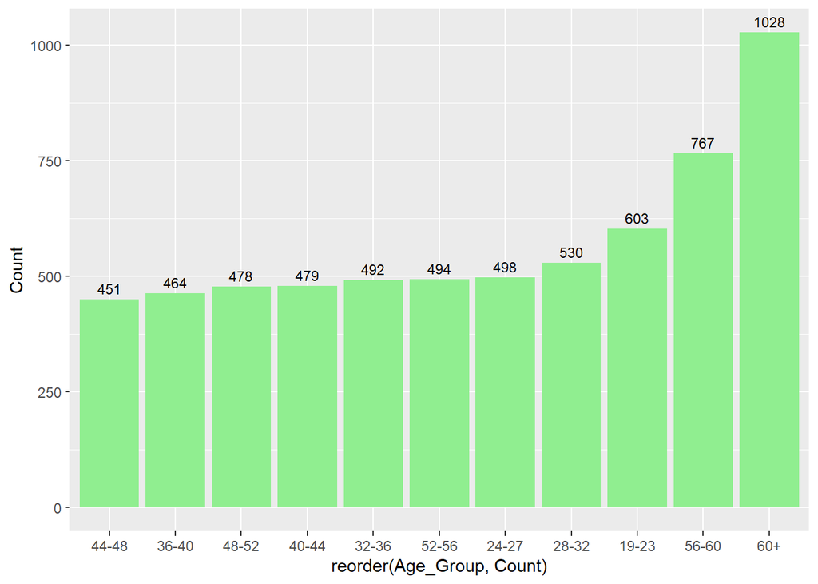

```r
employee_latest_record$Age_Group <- cut(employee_latest_record$age, breaks = c(18, 24, 28, 32, 36, 40, 44, 48, 52, 56, 60, max(employee_latest_record$age) + 1),
                      labels = c("19-23", "24-27", "28-32", "32-36", "36-40", "40-44", "44-48", "48-52", "52-56", "56-60", "60+"))

age_count_df <- employee_latest_record %>% group_by(Age_Group) %>% summarize(Count = n())

ggplot(age_count_df, aes(x=reorder(Age_Group,Count), y=Count))+
  geom_bar(stat="identity",fill="lightgreen")+
  geom_text(aes(label=Count) ,vjust = -0.5, size = 3)
```

There is no outliers

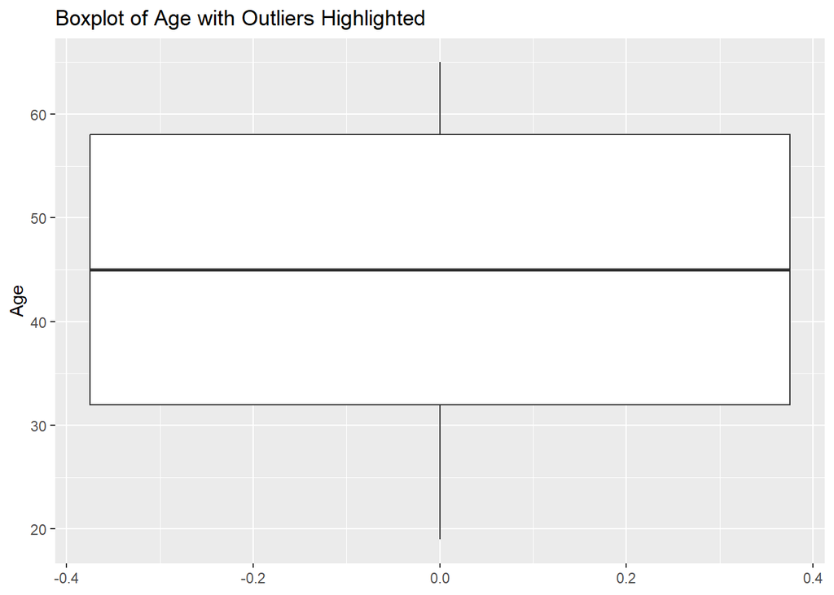

```r
# Assuming you have a variable 'age' in your dataset

ggplot(employee_latest_record, aes(y = age)) +
  geom_boxplot() +
  geom_text(data = subset(employee_latest_record, age > quantile(age, 0.75) + 1.5 * IQR(age) | age < quantile(age, 0.25) - 1.5 * IQR(age)),
            aes(label = age), hjust = -0.5, vjust = 0.5, color = "red") +
  ylab("Age") +
  labs(title = "Boxplot of Age with Outliers Highlighted")
```

Average Length of service

```r
average_length_of_service <- mean(employee_latest_record$length_of_service)
print(paste("The average length of service is ", round(average_length_of_service,2), " years."))
```

```
## [1] "The average length of service is  12.84  years."
```

Attrition Rate

IGNORE THIS

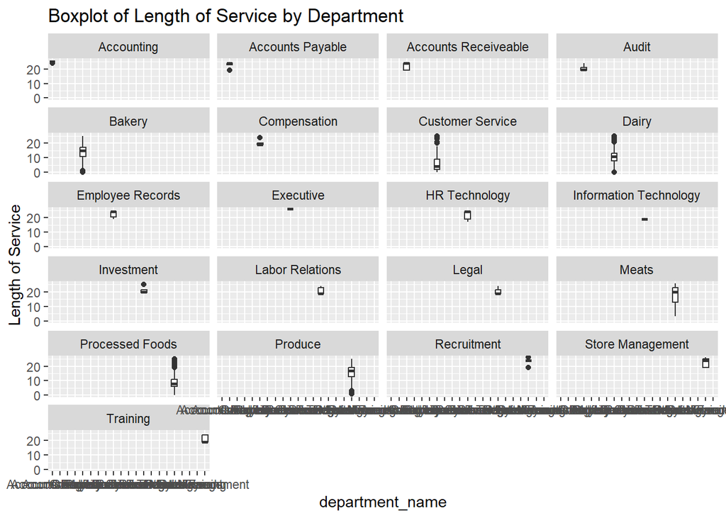

```r
length_of_service_over_departments <- employee_latest_record %>% group_by(department_name) %>% summarize(Count= n(),Mean = mean(length_of_service),Min = min(length_of_service),Max = max(length_of_service),OutlierCount = length(boxplot.stats(length_of_service)$out))


# Assuming employee_latest_record is a data frame with 'length_of_service' and 'department' variables

ggplot(employee_latest_record, aes(x = department_name, y = length_of_service)) +
  geom_boxplot() +
  geom_text(data = subset(employee_latest_record, length_of_service > quantile(length_of_service, 0.75) + 1.5 * IQR(length_of_service) | length_of_service < quantile(length_of_service, 0.25) - 1.5 * IQR(length_of_service)),
            aes(label = sprintf("%.2f", length_of_service)), hjust = -0.5, vjust = 0.5, color = "red") +
  ylab("Length of Service") +
  labs(title = "Boxplot of Length of Service by Department") +
  facet_wrap(~ department_name, 6)
```

[figure not shown]

```r
#since we have 37 job titles, i will only check for top 5 jobs with most employee

length_of_service_over_job<- employee_latest_record %>% group_by(job_title) %>% summarize(Count= n(),Mean = mean(length_of_service),Min = min(length_of_service),Max = max(length_of_service),OutlierCount = length(boxplot.stats(length_of_service)$out)) %>%
  arrange(desc(Count)) %>% top_n(5)
hiring_in_jobs_after_2006 <- employee_latest_record %>% group_by(job_title) %>% filter(orighiredate_key >="2006-01-01") %>% summarize(count = n())
hiring_in_jobs_since_2006 <- employee_latest_record %>% group_by(job_title) %>% summarize(count = n())




top5_departments <- length_of_service_over_job %>%
  top_n(5, wt = Count) %>%
  pull(job_title)

# Filter the original data for the top 5 departments
filtered_data <- employee_latest_record %>%
  filter(job_title %in% top5_departments, orighiredate_key >="2006-01-01")

# Create box plots
ggplot(filtered_data, aes(x = job_title, y = length_of_service)) +
  geom_boxplot() +
  ylab("Length of Service") +
  labs(title = "Boxplot of Length of Service in Top 5 Departments")
```

Business unit

```r
business_unit_count <- employee_latest_record %>% group_by(BUSINESS_UNIT) %>% count() %>% rename(counts = n)
business_unit_count
```

```
## # A tibble: 2 × 2
## # Groups:   BUSINESS_UNIT [2]
##   BUSINESS_UNIT counts
##   <chr>          <int>
## 1 HEADOFFICE        80
## 2 STORES          6204
```

departments in head office

```r
department_head_office <- employee_latest_record %>% filter(BUSINESS_UNIT == "HEADOFFICE") %>% group_by(department_name) %>% count() %>% rename(counts = n)
head(department_head_office,n=14)
```

```
## # A tibble: 14 × 2
## # Groups:   department_name [14]
##    department_name        counts
##    <chr>                   <int>
##  1 Accounting                  6
##  2 Accounts Payable            4
##  3 Accounts Receiveable        5
##  4 Audit                       4
##  5 Compensation                4
##  6 Employee Records            6
##  7 Executive                  10
##  8 HR Technology               9
##  9 Information Technology      5
## 10 Investment                  4
## 11 Labor Relations             6
## 12 Legal                       3
## 13 Recruitment                 9
## 14 Training                    5
```

```r
sum(department_head_office$counts)
```

```
## [1] 80
```

headoffice store name 14 active employees there

```r
head_office_store_name <- unique(employee_latest_record[employee_latest_record$BUSINESS_UNIT == "HEADOFFICE",]$store_name)
print(paste("The head office corresponds to the store name:",head_office_store_name))
```

```
## [1] "The head office corresponds to the store name: 35"
```

store management department has store manager

store without store management

```r
store_manager_data <- employee_latest_record[employee_latest_record$job_title == "Store Manager", ]
unique_store_names <- unique(store_manager_data$store_name)
all_store_names <- unique(employee_latest_record$store_name)
store_names_without_management <- setdiff(all_store_names,unique_store_names)
print(paste("There are total",length(all_store_names), "stores but, only",length(unique_store_names)," stores had a store manager"))
```

```
## [1] "There are total 46 stores but, only 35  stores had a store manager"
```

```r
active_store_manager <- store_manager_data %>% filter(STATUS == "ACTIVE")
print(paste("In 2015, there are only", count(active_store_manager)," active store managers."))
```

```
## [1] "In 2015, there are only 4  active store managers."
```

is there relation to stores with employee count

```r
store_employee_count <- employee_latest_record %>% filter(STATUS=="ACTIVE") %>%group_by(store_name) %>% count() %>% rename(counts = n) %>% arrange(desc(counts))
print(paste("The mean number of active employees in stores with managers are"))
```

[output not shown]

```r
store_employee_count_without_manager <- employee_latest_record %>% filter(store_name %in% store_names_without_management) %>% group_by(store_name) %>% count()

store_employee_count_without_manager_status <- employee_latest_record %>% filter(store_name %in% store_names_without_management) %>% group_by(store_name, STATUS) %>%
  summarise(counts = n(), .groups = "drop") %>%
  pivot_wider(names_from = STATUS, values_from = counts, names_prefix = "count_")
store_employee_count_without_manager
```

```
## # A tibble: 11 × 2
## # Groups:   store_name [11]
##    store_name     n
##         <int> <int>
##  1          4     1
##  2          7     6
##  3         10     2
##  4         11    47
##  5         22    81
##  6         23     7
##  7         24     9
##  8         34     5
##  9         35   221
## 10         40    72
## 11         43   311
```

```r
store_employee_count_without_manager
```

```
## # A tibble: 11 × 2
## # Groups:   store_name [11]
##    store_name     n
##         <int> <int>
##  1          4     1
##  2          7     6
##  3         10     2
##  4         11    47
##  5         22    81
##  6         23     7
##  7         24     9
##  8         34     5
##  9         35   221
## 10         40    72
## 11         43   311
```

```r
store_employee_count_without_manager_status
```

```
## # A tibble: 11 × 3
##    store_name count_TERMINATED count_ACTIVE
##         <int>            <int>        <int>
##  1          4                1           NA
##  2          7                6           NA
##  3         10                2           NA
##  4         11               47           NA
##  5         22               12           69
##  6         23                7           NA
##  7         24                9           NA
##  8         34                5           NA
##  9         35              207           14
## 10         40               10           62
## 11         43               24          287
```

stores with manager with varying jobttile

```r
store_job_count_without_manager <- employee_latest_record[(employee_latest_record$store_name %in% store_names_without_management),] %>% group_by(store_name) %>% summarise(unique_job = n_distinct(job_title))
store_job_count_without_manager
```

```
## # A tibble: 11 × 2
##    store_name unique_job
##         <int>      <int>
##  1          4          1
##  2          7          2
##  3         10          1
##  4         11         11
##  5         22         11
##  6         23          2
##  7         24          4
##  8         34          1
##  9         35         36
## 10         40         11
## 11         43         11
```

```r
store_job_count <- employee_latest_record %>% group_by(store_name) %>% summarise(unique_job = n_distinct(job_title))
store_job_count
```

```
## # A tibble: 46 × 2
##    store_name unique_job
##         <int>      <int>
##  1          1         12
##  2          2         10
##  3          3          6
##  4          4          1
##  5          5         12
##  6          6         12
##  7          7          2
##  8          8         12
##  9          9          6
## 10         10          1
## # ℹ 36 more rows
```

```r
store_category_by_jobs <- c(unique(store_job_count$unique_job))

for (job_count in store_category_by_jobs){
  store_with_job_count = store_job_count[store_job_count$unique_job == job_count,]
  store_name<- store_with_job_count$store_name[1]
  job_titles_for_store <- unique(employee_latest_record[employee_latest_record$store_name == store_name,]$job_title)
  print(paste("the job titles for store", store_name," with ",job_count,"job titles are: "))
  print(job_titles_for_store)

}
```

```
## [1] "the job titles for store 1  with  12 job titles are: "
##  [1] "Store Manager"            "Meats Manager"
##  [3] "Produce Manager"          "Bakery Manager"
##  [5] "Dairy Person"             "Processed Foods Manager"
##  [7] "Customer Service Manager" "Meat Cutter"
##  [9] "Produce Clerk"            "Shelf Stocker"
## [11] "Baker"                    "Cashier"
## [1] "the job titles for store 2  with  10 job titles are: "
##  [1] "Store Manager"           "Meats Manager"
##  [3] "Produce Manager"         "Dairy Person"
##  [5] "Processed Foods Manager" "Meat Cutter"
##  [7] "Produce Clerk"           "Baker"
##  [9] "Shelf Stocker"           "Cashier"
## [1] "the job titles for store 3  with  6 job titles are: "
## [1] "Store Manager" "Meat Cutter"   "Baker"         "Cashier"
```

[output cut: 50 more lines]

the number of unique jobs can be used to categorize the stores like all stores with 1 job title is dariy person and so on….

stores with manager and tehir top 3 active and terminated job titles

```r
store_job_summary <- employee_latest_record %>%
  group_by(store_name, job_title, STATUS) %>%
  summarize(count = n(), .groups = "drop") %>%
  arrange(store_name, STATUS,desc(count))

# To get the top 3 job titles in each store by count:
top_3_job_titles <- store_job_summary %>%
  group_by(store_name,STATUS) %>%
  top_n(3, wt = count)


top_3_job_titles_store_with_manger <- top_3_job_titles[!(top_3_job_titles$store_name %in% store_names_without_management),]
# Now you have a summary of the top 3 job titles in each store by count.
```

Overall Attrition rate of the company

```r
count_status <- employee_latest_record %>% count(STATUS)

# Get the number of employee of 'TERMINATED' STATUS
terminated_count = count_status[count_status$STATUS == 'TERMINATED', 'n']
# Calculate the percentage of 'TERMINATED' status
terminated_count_percent <- (terminated_count / sum(count_status$n)) * 100

# Print the percentage
print(paste('The overall attrition rate of company is :', round(terminated_count_percent,2), '%'))
```

```
## [1] "The overall attrition rate of company is : 23.63 %"
```

Attrition Rate by gender

```r
count_status_by_gender <- employee_latest_record %>% group_by(gender_full) %>% count(STATUS)



# Get the number of Male employee of 'TERMINATED' STATUS
terminated_count_male = count_status_by_gender[count_status_by_gender$STATUS == 'TERMINATED' & count_status_by_gender$gender_full =='Male', 'n']
# Calculate the percentage of 'TERMINATED' status
terminated_count_percent_male <- (terminated_count_male / sum(count_status_by_gender[count_status_by_gender$gender_full =='Male','n']) * 100)

# Print the percentage
print(paste('The overall attrition rate of Male in the company is :', round(terminated_count_percent_male,2), '%'))
```

```
## [1] "The overall attrition rate of Male in the company is : 18.96 %"
```

```r
# Get the number of employee of Female 'TERMINATED' STATUS
terminated_count_female = count_status_by_gender[count_status_by_gender$STATUS == 'TERMINATED' & count_status_by_gender$gender_full =='Female', 'n']
# Calculate the percentage of 'TERMINATED' status
terminated_count_percent_female <- (terminated_count_female / sum(count_status_by_gender[count_status_by_gender$gender_full =='Female','n']) * 100)

# Print the percentage
print(paste('The overall attrition rate of Female in the company is :', round(terminated_count_percent_female,2), '%'))
```

```
## [1] "The overall attrition rate of Female in the company is : 27.91 %"
```

## Termination Reason Distribution

Termination Reason Distribution

```r
terminated_employees = employee_latest_record %>% filter(STATUS == 'TERMINATED')
dim(terminated_employees)
```

```
## [1] 1485   19
```

```r
terminated_employees_reason = terminated_employees %>% group_by(termreason_desc) %>% count()
for (i in c(1:3)){
  print(paste('There were',terminated_employees_reason[i,][2],terminated_employees_reason[i,][1]))
}
```

```
## [1] "There were 215 Layoff"
## [1] "There were 385 Resignaton"
## [1] "There were 885 Retirement"
```

```r
terminated_employees_type = terminated_employees %>% group_by(termtype_desc) %>% count()

for (i in c(1:2)){
  print(paste('There were',terminated_employees_type[i,][2],terminated_employees_type[i,][1]))
}
```

```
## [1] "There were 215 Involuntary"
## [1] "There were 1270 Voluntary"
```

There are 215 layoff and 215 involuntary exits.

No need to verify but still

```r
count(terminated_employees[terminated_employees$termreason_desc =='Layoff' & terminated_employees$termtype_desc == 'Involuntary' ,])
```

```
##     n
## 1 215
```

lets see the layoff over years

```r
terminated_employees_layoff = terminated_employees %>% filter(termreason_desc =='Layoff') %>% group_by(STATUS_YEAR) %>% count()
terminated_employees_layoff
```

```
## # A tibble: 2 × 2
## # Groups:   STATUS_YEAR [2]
##   STATUS_YEAR     n
##         <int> <int>
## 1        2014   142
## 2        2015    73
```

It is found that there were layoffs only in 2014 and 2015. lets check the same for resignation

```r
resignation_by_year= terminated_employees %>% filter(termreason_desc =='Resignaton') %>% group_by(STATUS_YEAR) %>% count()
resignation_by_year
```

```
## # A tibble: 10 × 2
## # Groups:   STATUS_YEAR [10]
##    STATUS_YEAR     n
##          <int> <int>
##  1        2006    12
##  2        2007    25
##  3        2008    26
##  4        2009    18
##  5        2010    29
##  6        2011    69
##  7        2012    76
##  8        2013    49
##  9        2014    55
## 10        2015    26
```

lets visualize this

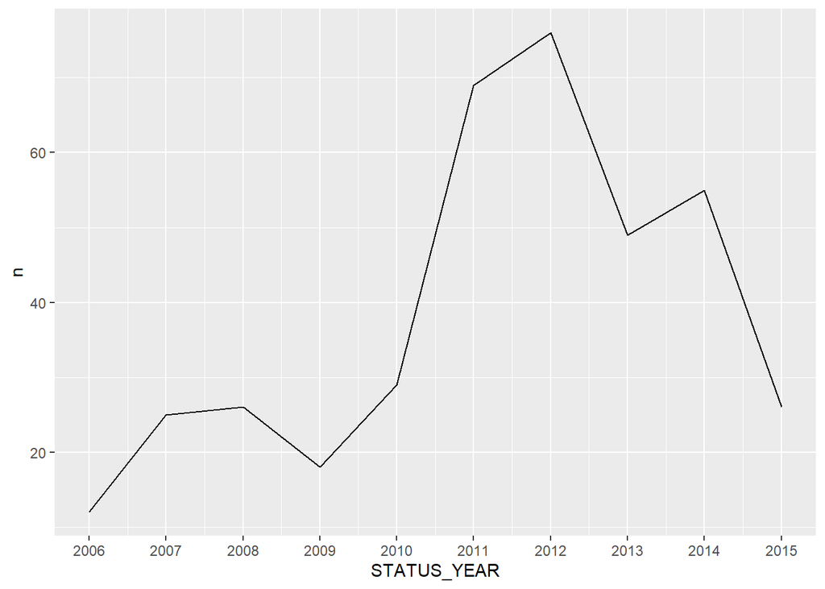

```r
resignaton_plot = ggplot(resignation_by_year, aes(x=STATUS_YEAR, y=n))+geom_line()+scale_x_continuous(breaks=seq(2006,2016,1))
resignaton_plot
```

```r
terminated_employees_resignation <- terminated_employees[terminated_employees$termreason_desc == 'Resignaton',]
resignation_by_department <- terminated_employees_resignation %>% group_by(STATUS_YEAR, department_name) %>% summarise(counts = n()) %>% arrange(STATUS_YEAR, desc(counts)) %>% group_by(STATUS_YEAR)
```

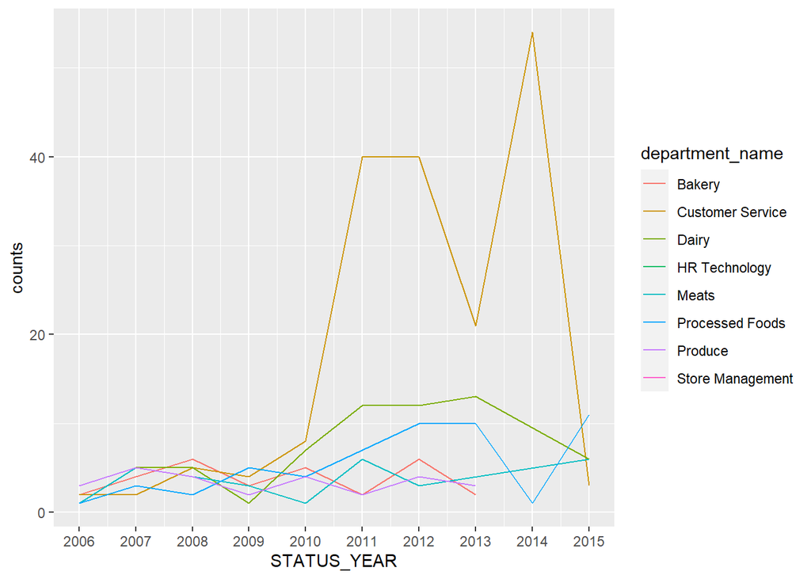

```r
p <- ggplot(resignation_by_department, aes(x=STATUS_YEAR, y= counts)) +geom_line(aes(color=department_name))+scale_x_continuous(breaks=seq(2006,2016,1))
p
```

In 2014 alone there were 55 resignaton of which 54 were customer_service

```r
terminated_employees_resignation[terminated_employees_resignation$STATUS_YEAR == 2014,]%>% group_by(department_name) %>% summarise(counts = n())
```

```
## # A tibble: 2 × 2
##   department_name  counts
##   <chr>             <int>
## 1 Customer Service     54
## 2 Processed Foods       1
```

department with most resignation

```r
department_resignation = terminated_employees %>% filter( termreason_desc =='Resignaton') %>% group_by(department_name) %>% summarise(resignaton_count = n()) %>% arrange(desc(resignaton_count))
```

job with most resgination

```r
job_resignation = terminated_employees %>% filter( termreason_desc =='Resignaton') %>% group_by(job_title) %>% summarise(resignaton_count = n()) %>% arrange(desc(resignaton_count))
```

age group with most resgination

```r
age_resignation = terminated_employees %>% filter( termreason_desc =='Resignaton') %>% group_by(age) %>% summarise(resignaton_count = n()) %>% arrange(desc(resignaton_count)) %>% top_n(3,resignaton_count)
```

The top 3 age of resgintion were 30,21,23 which is nearly 43% of all resignation and top 7 age is under 30 with 63% of all resgination

department wise customer what has more resignation and is there any relation to length of service

# this is irrelevant below

lets try to find the department and job titles each of the top 3 age work in

```r
department_resignation_age_21 <- terminated_employees %>% filter(termreason_desc =='Resignaton' & age==21) %>% group_by(department_name) %>% summarize(count = n())
department_resignation_age_23 <- terminated_employees %>% filter(termreason_desc =='Resignaton' & age==23) %>% group_by(department_name) %>% summarize(count = n())
department_resignation_age_30 <- terminated_employees %>% filter(termreason_desc =='Resignaton' & age==30) %>% group_by(department_name) %>% summarize(count = n())
```

age when they joined ## creating join_age feature

```r
terminated_employees['join_age'] = as.integer( difftime(terminated_employees$orighiredate_key, terminated_employees$birthdate_key, units = "days")/365.25)
```

```r
#age_21_terminated<- terminated_employees %>% filter(age==21 & join_age == 21 ) %>% group_by(department_name) %>% summarize(count = n())
```

most of the age 21 employees who resgined are involved in customer service 58 out of 60 most of the age 23 employees who resgined are involved in customer service 30 out of 33

filtering which city has most termiantion

```r
city_terminated <- terminated_employees %>% group_by(city_name)%>% summarize(count = n())%>% arrange(desc(count))
```

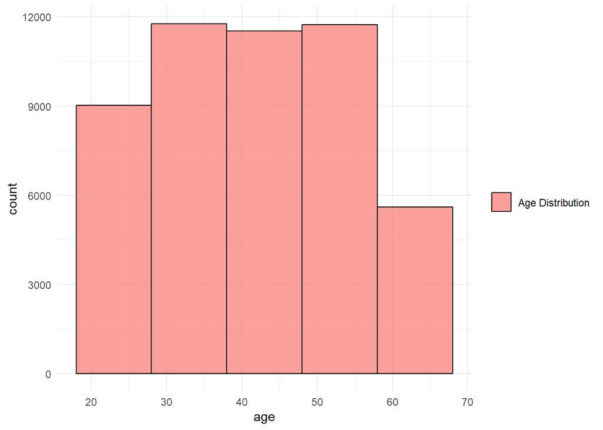

```r
p <- ggplot(employee_data, aes(x = age, , fill = "Age Distribution")) +
  geom_histogram( breaks= seq(from=18, to=70,by=10),color = "black", alpha = 0.7) +
  labs(fill = NULL) +  # Remove legend title
  theme_minimal()  # Apply a minimal theme
p
```

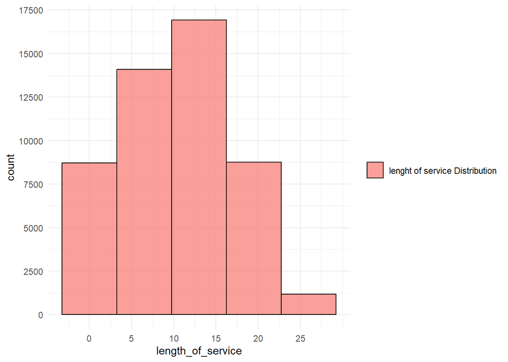

```r
p <- ggplot(employee_data, aes(x = length_of_service, , fill = "lenght of service Distribution")) +
  geom_histogram(bins=5,color = "black", alpha = 0.7) +
  labs(fill = NULL) +  # Remove legend title
  scale_x_continuous(breaks = seq(0, max(employee_data$length_of_service),5))+
  scale_y_continuous(breaks = seq(0, max(table(cut(employee_data$length_of_service, breaks = 5)))+5000, by = 2500))+
  theme_minimal()  # Apply a minimal theme
p
```

trying to see if age is a significant factor

```r
employee_latest_record$Age_Group <- cut(employee_latest_record$age, breaks = c(18, 24, 28, 32, 36, 40, 44, 48, 52, 56, 60, max(employee_latest_record$age) + 1),
                      labels = c("19-23", "24-27", "28-32", "32-36", "36-40", "40-44", "44-48", "48-52", "52-56", "56-60", "60+"))

# Calculate attrition rates for each age group
attrition_rates <- employee_latest_record %>%
  group_by(Age_Group) %>%
  summarize(Attrition_Rate = mean(STATUS == "TERMINATED"))

# Perform a statistical test (e.g., ANOVA) to determine if the differences in attrition rates are significant
# Install the "stats" package if not already installed
# install.packages("stats")
library(stats)

# Analysis of Variance (ANOVA)
anova_model <- aov(Attrition_Rate ~ Age_Group, data = attrition_rates)

# Check for significance
summary(anova_model)
```

```
##             Df Sum Sq Mean Sq
## Age_Group   10 0.3271 0.03271
```